# Task 2: Parameter Estimation (PELEGRI)

Patrick Pelegri-O’Day

1/31/2022

### Overview

This report uses non-linear least squares to estimate parameters of model of lizard weight based on lizard snout-to-vent length for lizard populations in New Mexico. First, a model is created based on the entire data set including both male and female lizards across 13 species. Then, a model is created only using data on male Western Whiptail lizards (*Cnemidophorus tigrisatus*). The two models are compared for their accuracy in predicting weights of male Western Whiptail lizards.

**Data Source:** Lightfoot, D. and W.G. Whitford. 2020. Lizard pitfall trap data from 11 NPP study locations at the Jornada Basin LTER site, 1989-2006 ver 37. Environmental Data Initiative. https://doi.org/10.6073/pasta/4a6e258fb49c31e222ecbbcfd128967f

```r
knitr::opts_chunk$set(echo = TRUE, message = FALSE, warning = FALSE)

library(here)
library(purrr)
library(tidyverse)
library(Metrics)
library(patchwork)
library(modelr)
library(broom)
library(kableExtra)
```

```r
lizards_raw <- read_csv(here("data", "lizard.csv"))
```

### General Model

#### OLS model for parameter estimation

Our conceptual model relating lizard weight (W) and lizard snout-vent length (SVL) is:
$$\begin{equation}
W=a(SVL)^b
\end{equation}$$
We want to estimate parameters a and b. To do so, we take the natural log of both sides. ln(weight) = ln(a(length)$^b$). This is equal to ln(weight) = b * ln(a) + b * ln(length)

We can use OLS to get an estimate for *a* and *b*. *b* will simply be the estimated coefficient for ln(length) once we run OLS. *b* * ln(*a*) will be equal to the intercept estimate from our OLS model. Thus, the estimate for *a* will be equal to $e^β/b$, where β is the y-intercept estimate

```r
lizards <- lizards_raw %>%
  mutate(log_length = log(SV_length)) %>%
  mutate(log_weight = log(weight))
```

```r
# Create initial OLS model using log variables in order to generate guess of NLS model parameters
my_guess_model <- lm(log_weight ~ log_length, data = lizards)
guess_coeffs <- coef(my_guess_model)
```

#### Create general NLS model

Parameter estimates from the OLS model are used as initial parameter guesses for creating the general NLS model. This NLS model is “general” in that it is trained on a dataset including all species of lizards and both sexes.

```r
# Define weight to length model for lizards
calc_weight <- function(a, SVL, b){
 W = a*SVL^b
return(W)
}

lizards_nls = nls(weight ~ calc_weight(a, SV_length, b),
                  data = lizards,
                  start = list(a = exp(guess_coeffs[1]/guess_coeffs[2]),
                               b = guess_coeffs[2]),
                  trace = TRUE)
```

```
## 2.307392e+09 (3.87e+02): par = (0.03541633 2.537119)
## 37257.95    (1.19e+00): par = (0.000345881 2.536411)
## 15903.53    (1.68e-01): par = (0.0003460122 2.464334)
## 15467.24    (5.36e-03): par = (0.0003446172 2.451287)
## 15466.81    (5.15e-04): par = (0.0003404191 2.45366)
## 15466.80    (1.18e-04): par = (0.0003412931 2.453084)
## 15466.80    (2.88e-05): par = (0.0003410855 2.453225)
## 15466.80    (7.08e-06): par = (0.0003411367 2.453191)
```

##### **Table 1.** Estimated parameters of the general NLS model. Each parameter had a p value below 0.001.*

```r
# Create tidy version of lizards_nls, then create table
# All p-values were extremely small; the ifelse renames them for readability
lizards_nls_tidy <- tidy(lizards_nls)

lizards_nls_tidy$p.value <- ifelse(lizards_nls_tidy$p.value < .001, paste("<0.001"))

lizards_nls_tidy %>%
  select(-statistic) %>%
  kable(col.names = c("Parameter", "Estimate",
                      "Standard Error", "P Value"), digits = 4) %>%
  kable_styling(bootstrap_options = "striped",
                position = "left", full_width = FALSE)
```

| Parameter | Estimate | Standard Error | P Value |
| --- | --- | --- | --- |
| a | 0.0003 | 0.000 | <0.001 |
| b | 2.4532 | 0.027 | <0.001 |

Predicted lizard weight values are generated from the general NLS model. Predicted values are compared to observed lizard weights to visualize model performance.

```r
# Create vector of predicted values for weight
lizards_pred_v <- predict(lizards_nls)

# Append original lizards df with lizards_pred_v
lizards_pred_df <- lizards %>%
  mutate(pred_weight = lizards_pred_v)
```

**Customize colors**

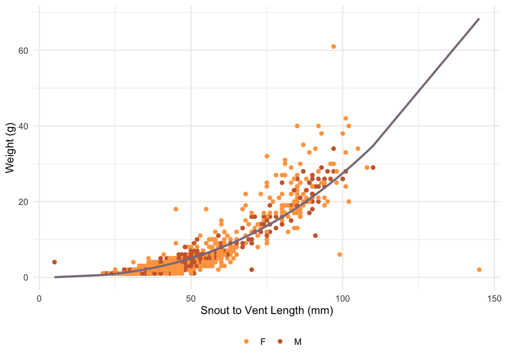

```r
# Graph predicted weight vs actual weight
ggplot(data = lizards_pred_df,
       aes(x = SV_length, y = lizards_pred_v)) +
  geom_point(aes(x = SV_length, y = weight, color = sex),
             size = 1.5) +
  scale_color_manual(values = c('tan1', 'sienna3')) +
  geom_line(color = 'thistle4', size = 1) +
  theme_minimal() +
  theme(legend.title = element_blank(),
        legend.position = "bottom") +
  labs(x = "Snout to Vent Length (mm)",
       y = "Weight (g)")
```

##### **Figure 1:** *Observed weight of lizards separated by sex and a fitted non-linear least squares model (the purple line) that predicts weight from snout-vent length.*

This graph shows that the fitted model predicts lizard weight from snout-vent length reasonably well.

### Species-specific NLS model

Another NLS model is created using the same initial parameter guesses as were used by the general NLS model. This model is trained on a subset of the data that only includes male Western Whiptail lizards.

```r
# Filter dataset for male Western Whiptail lizard
lizards_mWW_df <- lizards_raw %>%
  filter(sex == "M", spp == "CNTI") %>%
  mutate(log_length = log(SV_length)) %>%
  mutate(log_weight = log(weight))

# Create modified OLS model using log variables in order to generate guess of NLS model parameters
lm_guess_mWW <- lm(log_weight ~ log_length, data = lizards)
guess_coeffs_mWW <- coef(lm_guess_mWW)

# Redefine lizards_nls function for new subset df
lizards_mWW_nls = nls(weight ~ calc_weight(a, SV_length, b),
                  data = lizards_mWW_df,
                  start = list(a = exp(guess_coeffs_mWW[1]/guess_coeffs_mWW[2]),
                               b = guess_coeffs_mWW[2]),
                  trace = TRUE)
```

```
## 5.470999e+08 (8.24e+02): par = (0.03541633 2.537119)
## 19591.00    (4.83e+00): par = (0.0004581046 2.535804)
## 1527.420    (9.44e-01): par = (0.000459162 2.434398)
## 807.7503    (9.65e-03): par = (0.0005239174 2.371892)
## 807.6761    (7.69e-04): par = (0.000532293 2.367968)
## 807.6756    (2.34e-05): par = (0.0005314971 2.36833)
## 807.6756    (2.08e-06): par = (0.0005315783 2.368296)
```

```r
# Create vector of predicted values for weight
lizards_mWW_pred_v <- predict(lizards_mWW_nls)

# Append original lizards_mWW_df with lizards_pred_v
lizards_mWW_pred_df <- lizards_mWW_df %>%
  mutate(pred_weight_mWW = lizards_mWW_pred_v)
```

### Model comparison

The two models are compared by comparing the predicted weight values for male Western Whiptail lizards generated by two models and the observed weight values.

```r
lizards_compare_df <- lizards_pred_df %>%
  filter(spp == "CNTI", sex == 'M') %>%
  mutate(pred_weight_gen = pred_weight) %>%
  mutate(pred_weight_mWW = lizards_mWW_pred_v)
```

**Customize colors**

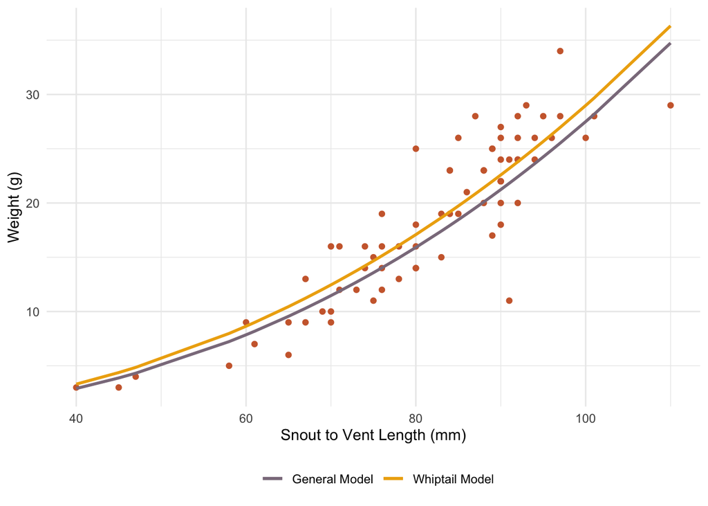

```r
# Graph predictions from general model vs mWW-specific model
ggplot(lizards_compare_df) +
  geom_point(aes(x = SV_length, y = weight),
             color = "sienna3",
             size = 1.5) +
  geom_line(aes(x = SV_length, y = pred_weight_gen,
                color = "General Model"), size = 1) +
  geom_line(aes(x = SV_length, y = pred_weight_mWW,
                color = "Whiptail Model"), size = 1) +
  scale_colour_manual(values =
                      c("General Model" = "thistle4",
                        "Whiptail Model" = "darkgoldenrod2")) +
  theme_minimal() +
  theme(legend.title = element_blank(),
        legend.position = "bottom") +
  labs(x = "Snout to Vent Length (mm)",
       y = "Weight (g)")
```

##### **Figure 2:** *This graph shows the actual weight of lizards (red points) compared to predicted weights from both the whiptail-specific model (the yellow line) and the general model (purple line) from* **Figure 1**.

RMSE is calculated for each model to compare them.

```r
lizards_nls_gen_rmse <- rmse(model = lizards_nls, data = lizards_compare_df)
#  round(2)

lizards_nls_mWW_rmse <- rmse(model = lizards_mWW_nls, data = lizards_compare_df)
#  round(2)
```

The Whiptail-specific model predicts male Western Whiptail lizard weight more accurately than the general model: Whiptail-specific model RMSE =3.35; general model RMSE = 3.56). Thus, the Whiptail-specific model is a better option for predicting male Western Whiptail weights based on snout-vent length.